# K1_STAT_multiple_regression

#### 6.6.1.2 Package `jtools`

https://cran.r-project.org/web/packages/jtools/vignettes/summ.html

```r
library(jtools)

jtools:::summ(fit1)
```

| Observations | 1243 |
| --- | --- |
| Dependent variable | children |
| Type | OLS linear regression |

| F(2,1240) | 33.34 |
| --- | --- |
| R² | 0.05 |
| Adj. R² | 0.05 |

|  | Est. | S.E. | t val. | p |
| --- | --- | --- | --- | --- |
| (Intercept) | 6.15 | 0.48 | 12.94 | 0.00 |
| years_school | -0.21 | 0.05 | -4.63 | 0.00 |
| age_marriage | -0.08 | 0.01 | -5.69 | 0.00 |

Standard errors: OLS

```r
jtools:::summ(fit1, robust = "HC3")
```

| Observations | 1243 |
| --- | --- |
| Dependent variable | children |
| Type | OLS linear regression |

| F(2,1240) | 33.34 |
| --- | --- |
| R² | 0.05 |
| Adj. R² | 0.05 |

|  | Est. | S.E. | t val. | p |
| --- | --- | --- | --- | --- |
| (Intercept) | 6.15 | 0.55 | 11.22 | 0.00 |
| years_school | -0.21 | 0.05 | -4.48 | 0.00 |
| age_marriage | -0.08 | 0.01 | -5.40 | 0.00 |

Standard errors: Robust, type = HC3

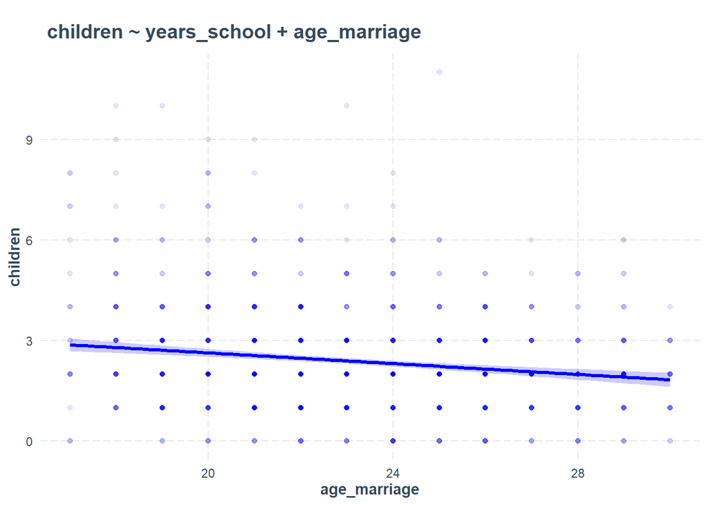

```r
p1 <- jtools:::effect_plot(fit1,
                     pred = age_marriage,
                     interval = TRUE,
                     plot.points = TRUE,
                     jitter = 0,
                     point.alpha = 0.1,
                     colors = c("blue"),
                      main.title = "children ~ years_school + age_marriage")

p1
```

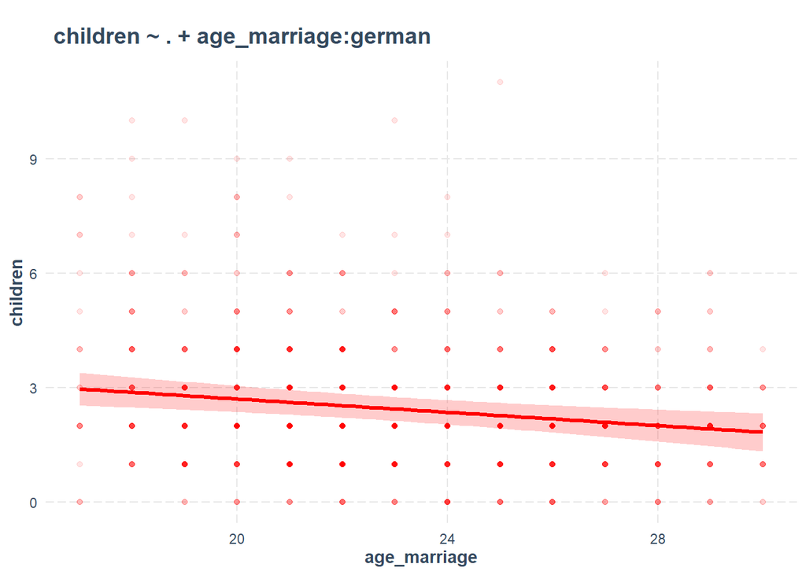

```r
p2 <- jtools:::effect_plot(fit8a,
                     pred = age_marriage,
                     interval = TRUE,
                     plot.points = TRUE,
                     jitter = 0,
                     point.alpha = 0.1,
                     colors = c("red"),
                      main.title = "children ~ . + age_marriage:german")
p2
```

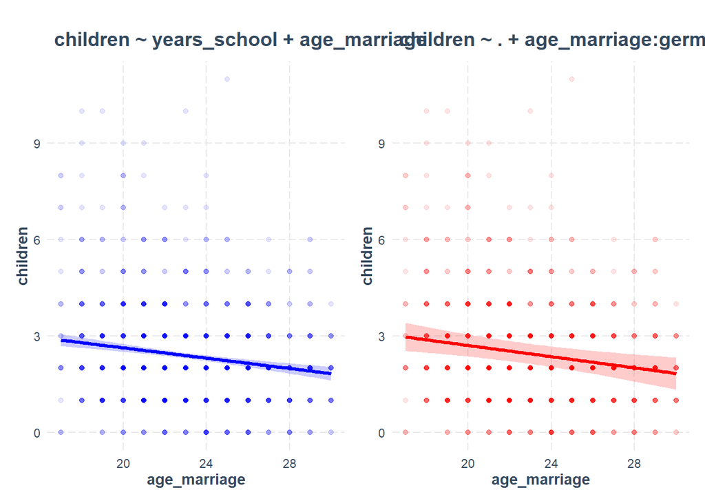

```r
library(patchwork)

p1 + p2
```

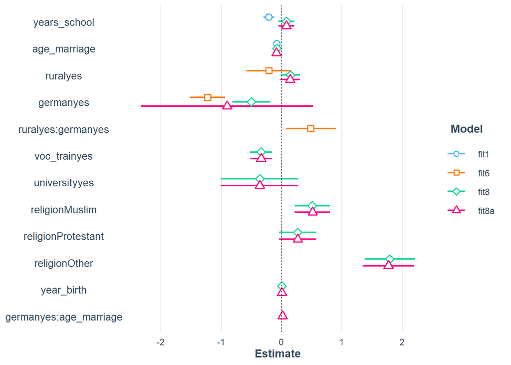

```r
jtools:::plot_summs(fit1,
                    fit6,
                    fit8,
                    fit8a,
                    model.names = c("fit1", "fit6", "fit8", "fit8a"))
```

```r
jtools:::export_summs(fit1,
                    fit6,
                    fit8,
                    fit8a,
                    statistics = c(N = "nobs",
                                   R2 = "r.squared",
                                   "logLik",
                                   "AIC",
                                   "BIC"),
                    model.names = c("fit1", "fit6", "fit8", "fit8a")
                    # to.file = "docx",
                    # file.name = "compare_model_jtools.docx"
                    )
```

|  | fit1 | fit6 | fit8 | fit8a |
| --- | --- | --- | --- | --- |
| (Intercept) | 6.15 *** | 3.28 *** | 3.11 *** | 3.43 *** |
|  | (0.48) | (0.13) | (0.63) | (0.85) |
| years_school | -0.21 *** |  | 0.08 | 0.08 |
|  | (0.05) |  | (0.07) | (0.07) |
| age_marriage | -0.08 *** |  | -0.07 *** | -0.09 ** |
|  | (0.01) |  | (0.01) | (0.03) |
| ruralyes |  | -0.21 | 0.15 | 0.14 |
|  |  | (0.19) | (0.08) | (0.08) |
| germanyes |  | -1.23 *** | -0.50 ** | -0.90 |
|  |  | (0.15) | (0.16) | (0.73) |
| ruralyes:germanyes |  | 0.48 * |  |  |
|  |  | (0.21) |  |  |
| voc_trainyes |  |  | -0.34 *** | -0.34 *** |
|  |  |  | (0.09) | (0.09) |
| universityyes |  |  | -0.36 | -0.36 |
|  |  |  | (0.33) | (0.33) |
| religionMuslim |  |  | 0.51 *** | 0.51 *** |
|  |  |  | (0.15) | (0.15) |
| religionProtestant |  |  | 0.27 | 0.27 |
|  |  |  | (0.16) | (0.16) |
| religionOther |  |  | 1.79 *** | 1.77 *** |
|  |  |  | (0.21) | (0.22) |
| year_birth |  |  | 0.01 | 0.01 |
|  |  |  | (0.01) | (0.01) |
| germanyes:age_marriage |  |  |  | 0.02 |
|  |  |  |  | (0.03) |
| N | 1243 | 1243 | 1243 | 1243 |
| R2 | 0.05 | 0.07 | 0.16 | 0.16 |
| logLik | -2256.41 | -2242.06 | -2181.82 | -2181.66 |
| AIC | 4520.82 | 4494.12 | 4387.64 | 4389.31 |
| BIC | 4541.32 | 4519.75 | 4449.14 | 4455.94 |
| *** p < 0.001; ** p < 0.01; * p < 0.05. |  |  |  |  |

### 6.6.2 Variable important

```r
library(caret)

caret:::varImp(fit8)
```

```
                    Overall
germanyes          3.147202
years_school       1.202672
voc_trainyes       3.679215
universityyes      1.100820
religionMuslim     3.427745
religionProtestant 1.699329
religionOther      8.406552
year_birth         1.167922
ruralyes           1.761643
age_marriage       5.262375
```

```r
caret:::varImp(fit8) |> dplyr:::arrange(Overall) -> var_imp_data
```

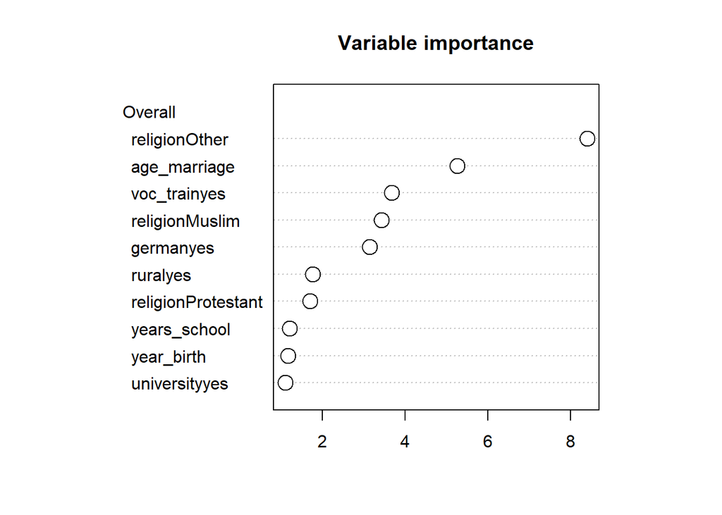

```r
# colnames(var_imp_data) <- ""

par(pty = "s")
graphics:::dotchart(as.matrix(var_imp_data),
         main = "Variable importance",
         pt.cex = 2)
```

### 6.6.3 Variable selection | stepwise regression

#### 6.6.3.1 package `olsrr`

https://olsrr.rsquaredacademy.com/

```r
library(olsrr)

# step1 <- ols_step_both_p(fit8,
#                          p_enter = 0.01,
#                          p_remove = 0.05,
#                          details = TRUE)

step1 <- olsrr:::ols_step_forward_p(fit8,
                         p_enter = 0.01,
                         p_remove = 0.05,
                         details = TRUE)
```

```
Forward Selection Method
------------------------

Candidate Terms:

1. german
2. years_school
3. voc_train
4. university
5. religion
6. year_birth
7. rural
8. age_marriage


Step   => 0
Model  => children ~ 1
R2     => 0

Initiating stepwise selection...

                      Selection Metrics Table
-------------------------------------------------------------------
Predictor       Pr(>|t|)    R-Squared    Adj. R-Squared      AIC
-------------------------------------------------------------------
religion         0.00000        0.113             0.111    4439.116
german           0.00000        0.065             0.065    4499.835
voc_train        0.00000        0.041             0.040    4532.164
age_marriage     0.00000        0.035             0.034    4540.103
years_school     0.00000        0.026             0.025    4550.909
year_birth       0.03609        0.004             0.003    4579.533
rural            0.04781        0.003             0.002    4580.010
university       0.23094        0.001             0.000    4582.497
-------------------------------------------------------------------

Step      => 1
Selected  => german
Model     => children ~ german
R2        => 0.065

```

[output cut: 84 more lines]

```
years_school     0.52213        0.158             0.151    4386.858
university       0.67551        0.157             0.151    4387.095
-------------------------------------------------------------------


No more variables to be added.

Variables Selected:

=> german
=> age_marriage
=> religion
=> voc_train
=> rural
=> year_birth
```

```r
step1
```

```
                                Stepwise Summary
------------------------------------------------------------------------------
Step    Variable          AIC         SBC         SBIC        R2       Adj. R2
------------------------------------------------------------------------------
 0      Base Model      4581.934    4592.185    1054.106    0.00000    0.00000
 1      german          4499.835    4515.211     971.971    0.06542    0.06467
 2      age_marriage    4470.869    4491.370     942.967    0.08842    0.08695
 3      religion        4401.737    4437.614     870.172    0.14188    0.13841
 4      voc_train       4385.804    4426.806     854.362    0.15417    0.15007
 5      rural           4384.875    4431.002     853.469    0.15617    0.15138
 6      year_birth      4385.272    4436.524     853.897    0.15725    0.15179
------------------------------------------------------------------------------

Final Model Output
------------------

                         Model Summary
----------------------------------------------------------------
R                       0.397       RMSE                  1.401
R-Squared               0.157       MSE                   1.962
Adj. R-Squared          0.152       Coef. Var            58.976
Pred R-Squared          0.144       AIC                4385.272
MAE                     1.008       SBC                4436.524
----------------------------------------------------------------
 RMSE: Root Mean Square Error
 MSE: Mean Square Error
 MAE: Mean Absolute Error
 AIC: Akaike Information Criteria
 SBC: Schwarz Bayesian Criteria

                                ANOVA
----------------------------------------------------------------------
                Sum of
               Squares          DF    Mean Square      F         Sig.
----------------------------------------------------------------------
Regression     455.082           8         56.885    28.782    0.0000
Residual      2438.869        1234          1.976
Total         2893.952        1242
----------------------------------------------------------------------

                                      Parameter Estimates
-----------------------------------------------------------------------------------------------
             model      Beta    Std. Error    Std. Beta      t        Sig      lower     upper
-----------------------------------------------------------------------------------------------
       (Intercept)     3.735         0.364                 10.256    0.000     3.020     4.449
         germanyes    -0.420         0.140       -0.109    -2.997    0.003    -0.695    -0.145
      age_marriage    -0.074         0.014       -0.148    -5.317    0.000    -0.101    -0.046
    religionMuslim     0.502         0.148        0.162     3.391    0.001     0.212     0.793
religionProtestant     0.262         0.157        0.085     1.667    0.096    -0.046     0.570
     religionOther     1.784         0.213        0.278     8.376    0.000     1.366     2.202
      voc_trainyes    -0.310         0.088       -0.101    -3.505    0.000    -0.483    -0.136
          ruralyes     0.144         0.082        0.047     1.761    0.078    -0.016     0.304
        year_birth     0.006         0.005        0.036     1.262    0.207    -0.003     0.016
-----------------------------------------------------------------------------------------------
```

```r
class(step1)
```

```
[1] "ols_step_forward_p"
```

```r
png(filename = "olsrr.png",
    width = 9,
    height = 9,
    units = "in",
    res = 300)

olsrr:::plot.ols_step_forward_p(step1)
```

```r
dev.off()
```

#### 6.6.3.2 package `StepReg`

https://cran.r-project.org/web/packages/StepReg/vignettes/StepReg.html

```r
library(StepReg)

formula(fit8)
```

```
children ~ german + years_school + voc_train + university + religion +
    year_birth + rural + age_marriage
```

```r
# formula <- children ~ .

res_ok <- StepReg:::stepwise(formula = formula(fit8),
                 data = dr,
                 type = "linear",
                 include = "rural",
                 strategy = "forward",
                 metric = "AIC")

res_ok$overview
```

```
$forward
$forward$AIC
  Step EffectEntered NumberEffect NumberParams         AIC
1    1             1            1            1 2297.453254
2    2         rural            2            2 2295.528784
3    3      religion            3            5  2150.92307
4    4  age_marriage            4            6 2124.901018
5    5     voc_train            5            7 2106.275294
6    6        german            6            8 2100.393491
```

```r
summary(res_ok$forward$AIC)
```

```
Call:
lm(formula = children ~ 1 + rural + religion + age_marriage +
    voc_train + german, data = data, weights = NULL)

Residuals:
    Min      1Q  Median      3Q     Max
-4.6825 -0.9002 -0.1422  0.6324  8.7686

Coefficients:
                   Estimate Std. Error t value Pr(>|t|)
(Intercept)         3.93237    0.32873  11.962  < 2e-16 ***
ruralyes            0.13942    0.08168   1.707 0.088079 .
religionMuslim      0.50226    0.14818   3.390 0.000722 ***
religionProtestant  0.26771    0.15698   1.705 0.088369 .
religionOther       1.78231    0.21308   8.364  < 2e-16 ***
age_marriage       -0.06892    0.01334  -5.168 2.76e-07 ***
voc_trainyes       -0.33030    0.08697  -3.798 0.000153 ***
germanyes          -0.38523    0.13744  -2.803 0.005145 **
---
Signif. codes:  0 '***' 0.001 '**' 0.01 '*' 0.05 '.' 0.1 ' ' 1

Residual standard error: 1.406 on 1235 degrees of freedom
Multiple R-squared:  0.1562,    Adjusted R-squared:  0.1514
F-statistic: 32.65 on 7 and 1235 DF,  p-value: < 2.2e-16
```

```r
png(filename = "stepreg.png",
    width = 9,
    height = 9,
    units = "in",
    res = 300)

plot_list <- setNames(
  lapply(c("forward"),function(i){
    setNames(
      lapply(c("detail","overview"),function(j){
        plot(res_ok,strategy=i,process=j)
    }),
    c("detail","overview")
    )
  }),
  c("forward")
)
cowplot::plot_grid(plotlist = plot_list$forward,
                   ncol = 1,
                   rel_heights = c(2, 1))

dev.off()
```

### 6.6.4 Variable selection | BMA

https://github.com/hanase/BMA

https://sites.stat.washington.edu/raftery/Research/bma.html

https://warwick.ac.uk/fac/sci/statistics/staff/academic-research/steel/steel_homepage/bma/

```r
library(BMA)

set.seed(1)


bma_out <- BMA:::bic.glm.formula(f =  children ~ .,
                                 data = dr,
                            strict = FALSE,
                            OR = 20,
                            glm.family = gaussian(link = "identity"))

summary(bma_out)
```

```
Call:
BMA:::bic.glm.formula(f = children ~ ., data = dr, glm.family = gaussian(link = "identity"),     strict = FALSE, OR = 20)


  5  models were selected
 Best  5  models (cumulative posterior probability =  1 ):

                     p!=0    EV         SD        model 1     model 2     model 3     model 4     model 5
Intercept            100     3.9297065  0.332685   3.991e+00   3.874e+00   3.932e+00   3.816e+00   3.807e+00
german                57.1
      .yes                  -0.2169892  0.214859  -3.776e-01       .      -3.852e-01       .      -4.099e-01
years_school           0.0   0.0000000  0.000000       .           .           .           .           .
voc_train            100.0
         .yes               -0.3802665  0.088989  -3.609e-01  -4.141e-01  -3.303e-01  -3.861e-01  -3.428e-01
university             0.0
          .yes               0.0000000  0.000000       .           .           .           .           .
religion             100.0
        .Muslim              0.4467640  0.159860   5.068e-01   3.680e-01   5.023e-01   3.610e-01   5.071e-01
        .Protestant          0.1815939  0.179776   2.688e-01   6.643e-02   2.677e-01   6.150e-02   2.632e-01
        .Other               1.8331292  0.221843   1.770e+00   1.914e+00   1.782e+00   1.929e+00   1.771e+00
year_birth             2.8   0.0001638  0.001275       .           .           .           .       5.899e-03
rural                 10.0
     .yes                    0.0136157  0.048346       .           .       1.394e-01   1.319e-01       .
age_marriage         100.0  -0.0688726  0.013359  -6.815e-02  -6.937e-02  -6.892e-02  -7.012e-02  -7.258e-02

nVar                                                 4           3           5           4           5
BIC                                               -7.567e+03  -7.566e+03  -7.563e+03  -7.562e+03  -7.561e+03
post prob                                          0.484       0.388       0.059       0.041       0.028

  1  observations deleted due to missingness.
```

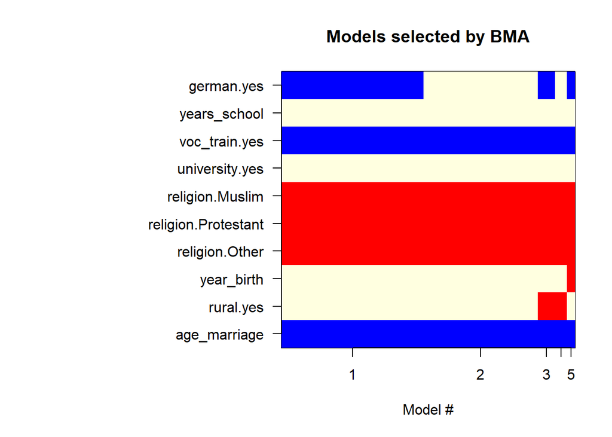

```r
par(oma = c(0, 10, 0, 0))
imageplot.bma(bma_out,
              color = c("red", "blue", "lightyellow"))
```

RED to use when the variable estimate is positive: risk factor (hệ số coef dương, sự kiện 1 dễ xảy ra, tỷ lệ thuận với biến outcome)

BLUE when the variable estimate is negative: protective factor (hệ số coef âm, sự kiện 1 ít xảy ra, tỷ lệ nghịch với biến outcome)

LIGHT YELLOW when the variable is not included in the model.

```r
# BMA:::plot.bic.glm(bma_out)
```

# 7 Mediation analysis

**Mặc dù áp dụng vào model mediation ta vẫn ra kết quả nhưng bản chất mô hình phân tích biến trung gian này bắt buộc biến trung gian “mediator” phải xuất hiện sau biến X, do đó ta không dùng cách tiếp cận này cho bài toán này được.**

```r
library(gtregression)


fit_med <- gtregression:::mediation_analysis(
  data = dr,
  exposure = university,
  mediator = age_marriage,
  outcome = children,
  covariates = NULL,
  # mediator_approach = "linear",
  outcome_approach = "linear",
  sims = 100,
  seed = 123
)

fit_med
```

```
a flextable object.
col_keys: `Effect`, `Estimate`, `95% CI`, `p-value`, `Interpretation`
header has 1 row(s)
body has 4 row(s)
original dataset sample:
'data.frame':   4 obs. of  5 variables:
 $ Effect        : chr  "Total effect" "Direct effect" "Indirect effect" "Proportion mediated"
 $ Estimate      : chr  "-0.309" "-0.109" "-0.201" "0.648"
 $ 95% CI        : chr  "-0.632 to 0.022" "-0.471 to 0.241" "-0.295 to -0.115" "-11.863 to 8.921"
 $ p-value       : chr  "0.120" "0.720" "<0.001" "0.120"
 $ Interpretation: chr  "Overall exposure-outcome association" "Association not through the mediator" "Association through the mediator" "Share of total effect through the mediator"
 - attr(*, "variable_labels")= Named chr [1:3] "university" "age_marriage" "children"
  ..- attr(*, "names")= chr [1:3] "university" "age_marriage" "children"
```

```r
fit_med$table
```

| Effect | Estimate | 95% CI | p-value | Interpretation |
| --- | --- | --- | --- | --- |
| Total effect | -0.309 | -0.632 to 0.022 | 0.120 | Overall exposure-outcome association |
| Direct effect | -0.109 | -0.471 to 0.241 | 0.720 | Association not through the mediator |
| Indirect effect | -0.201 | -0.295 to -0.115 | <0.001 | Association through the mediator |
| Proportion mediated | 0.648 | -11.863 to 8.921 | 0.120 | Share of total effect through the mediator |

Effects are mean differences from linear outcome models.  
Comparison: university = yes vs no; mediator = age_marriage; outcome = children. Bootstrap replicates = 100.  
No covariates included.  
Causal interpretation requires DAG-supported no-unmeasured-confounding and correct temporal-order assumptions.

```r
fit_med$table_body
```

```
               effect              Effect   estimate    conf.low   conf.high p.value
total           total        Total effect -0.3093759  -0.6319067  0.02204374    0.12
direct         direct       Direct effect -0.1087641  -0.4708801  0.24072887    0.72
indirect     indirect     Indirect effect -0.2006118  -0.2951794 -0.11452712    0.00
proportion proportion Proportion mediated  0.6484402 -11.8628209  8.92148653    0.12
                                       Interpretation
total            Overall exposure-outcome association
direct           Association not through the mediator
indirect             Association through the mediator
proportion Share of total effect through the mediator
```

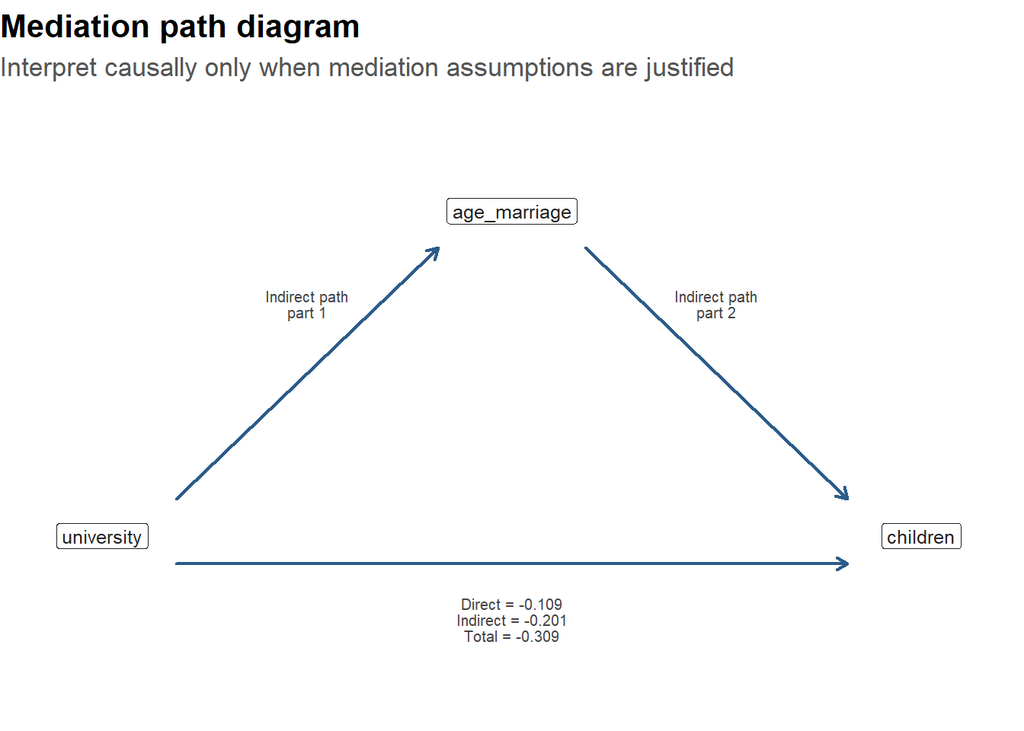

```r
plot_mediation(fit_med)
```

Chủ đề phân tích biến trung gian sẽ dành ở 1 dataset về bệnh sẽ phù hợp hơn.

https://cran.r-project.org/web/packages/gtregression/vignettes/causal-mediation.html

# 8 Confounder analysis

**Ta sẽ minh họa việc phân tích biến trung gian và biến gây nhiễu trong dataset về bệnh tiểu đường ở session về logistic regression.**

https://cran.r-project.org/web/packages/gtregression/vignettes/confounding-interaction.html

# 9 Phụ lục

## 9.1 Kiểm định hiện tượng tự tương quan của residual trong model hồi quy

Sử dụng function `car:::dwt()` Durbin-Watson Test for Autocorrelated Errors

Trong Durbin–Watson test, mục đích là kiểm tra hiện tượng tự tương quan (autocorrelation) của sai số (residuals/errors) trong mô hình hồi quy tuyến tính.

H0: Không có hiện tượng tự tương quan bậc 1 (first-order autocorrelation) giữa các sai số.

H1: Có hiện tượng tự tương quan bậc 1 (first-order autocorrelation) giữa các sai số.

Ý nghĩa chỉ số Durbin–Watson (DW)

Giá trị DW nằm trong khoảng từ 0 đến 4.

- DW ≈ 2 Không có autocorrelation
- DW < 2 Có xu hướng positive autocorrelation
- DW > 2 Có xu hướng negative autocorrelation
- DW ≈ 0 Positive autocorrelation mạnh
- DW ≈ 4 Negative autocorrelation mạnh

## 9.2 Kiểm định hiện tượng đa cộng tuyến (tự tương quan giữa các biến X) trong model hồi quy

Trong kết quả `car::vif()`, GVIF (Generalized Variance Inflation Factor) là hệ số dùng để đánh giá hiện tượng đa cộng tuyến (multicollinearity) giữa các biến độc lập trong mô hình multiple regression.

- VIF: sử dụng cho biến độc lập có 1 bậc tự do (1 degree of freedom)
- GVIF: sử dụng cho biến độc lập có nhiều bậc tự do (multiple degrees of freedom), là phiên bản tổng quát của VIF, được sử dụng khi mô hình có các biến độc lập dạng categorical với nhiều mức (factor).
- `GVIF^(1/(2*Df))` là chỉ số GVIF đã được điều chỉnh theo số bậc tự do (adjusted GVIF), giúp so sánh giữa các biến có bậc tự do khác nhau.

Nhìn chung các biến có chỉ số VIF < 5 thì không có đa cộng tuyến.

# 10 Tài liệu tham khảo

1. Homogeneity of Variance https://methods.sagepub.com/ency/edvol/encyc-of-research-design/chpt/homogeneity-variance
2. Package `interactions` https://interactions.jacob-long.com/articles/interactions